# Thomes Creek

Sadie Gill, Mark Tompkins

July 2020

## Future Data Improvements

None planned.

## Instream Spawning and Rearing Habitat

**Data Source:** [Calculated with a relationship between flow and mean weighted usable area from watersheds in the region with modeled habitat](http://cvpia-habitat-docs-markdown.s3-website-us-west-2.amazonaws.com/watershed/Regional_Approximation.html)

No watershed specific instream spawning or rearing habitat data was available for Thomes Creek. Instream spawning and rearing data were developed using similar watersheds in the Upper-mid Sacramento River Region to create a [regional approximation](http://cvpia-habitat-docs-markdown.s3-website-us-west-2.amazonaws.com/watershed/Regional_Approximation.html).

## Floodplain Rearing Habitat

**Data Source:** [Scaled USFWS / FEMA 1D HEC-RAS hydraulic model](https://s3-us-west-2.amazonaws.com/cvpiahabitat-r-package/cvpia-sit-model-inputs/CVPIA+Annual+Progress+Report+Fiscal+Year+2017.pdf)

### Fall Run

There was no watershed specific hydraulic modeling available for Thomes Creek. A flow to inundated floodplain area relationship was generated for Thomes Creek by scaling the flow to inundated floodplain area relationship for Cottonwood Creek. This scaling used the ratio of mean flow from December to June between the modeled and unmodeled watershed. Flows and corresponding inundated floodplain areas per unit length were calculated for Thomes Creek as 37% of Cottonwood Creek. Of the entire mapped 37.5 miles rearing extent in Thomes Creek, 37.5 miles were classified as low gradient and 0 miles were classified as high gradient based on a geomorphic analysis of long profile slopes and valley widths. The area per unit length was scaled by a factor of 0.1 for the high gradient extent. There was no scaling factor applied to the low gradient extent.

### Spring Run and Steelhead

There was no watershed specific hydraulic modeling available for Thomes Creek. A flow to inundated floodplain area relationship was generated for Thomes Creek by scaling the flow to inundated floodplain area relationship for Cottonwood Creek. This scaling used the ratio of mean flow from December to June between the modeled and unmodeled watershed. Flows and corresponding inundated floodplain areas per unit length were calculated for Thomes Creek as 37% of Cottonwood Creek. Of the entire mapped 42.7 miles rearing extent in Thomes Creek, 37.5 miles were classified as low gradient and 5.2 miles were classified as high gradient based on a geomorphic analysis of long profile slopes and valley widths. The area per unit length was scaled by a factor of 0.1 for the high gradient extent. There was no scaling factor applied to the low gradient extent.

## Floodplain Data

The areas represent total inundated area in acres.

Header Descriptions: flow_cfs = flow in cubic feet per second, FR_floodplain_acres = Fall Run Chinook floodplain acres, SR_floodplain_acres = Spring Run Chinook floodplain acres, ST_floodplain_acres = Steelhead floodplain acres, watershed = section of stream modeled for CVPIA SDM

| flow_cfs | FR_floodplain_acres | SR_floodplain_acres | ST_floodplain_acres | watershed |
| --- | --- | --- | --- | --- |
| 2795.443 | 0.000000 | 0.000000 | 0.000000 | Thomes Creek |
| 2927.859 | 3.643509 | 3.694287 | 3.694287 | Thomes Creek |
| 3060.275 | 8.174995 | 8.288925 | 8.288925 | Thomes Creek |
| 3192.690 | 11.875706 | 12.041210 | 12.041210 | Thomes Creek |
| 3325.106 | 14.920400 | 15.128336 | 15.128336 | Thomes Creek |

*… with 5 more rows*

## Floodplain Plot

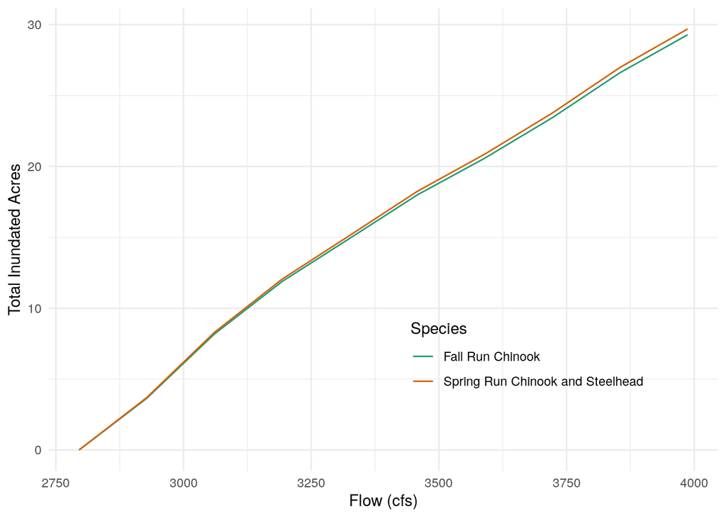